# Risk Factor Analysis

## Outcome Variable

**Outcome Variable:** sstunted

## Predictor Variables

**Intervention Variable:** mhtcm

**Adjustment Set:**

unadjusted

## Stratifying Variables

The analysis was stratified on these variable(s):

- agecat
- studyid
- country

## Data Summary

| agecat | studyid | country | A | n | nA | nAY0 | nAY1 |
| --- | --- | --- | --- | --- | --- | --- | --- |
| Birth | ki0047075b-MAL-ED | BANGLADESH | >=160 | 246 | 4 | 4 | 0 |
| Birth | ki0047075b-MAL-ED | BANGLADESH | <145 | 246 | 55 | 50 | 5 |
| Birth | ki0047075b-MAL-ED | BANGLADESH | [145-150) | 246 | 86 | 85 | 1 |
| Birth | ki0047075b-MAL-ED | BANGLADESH | [150-155) | 246 | 80 | 80 | 0 |
| Birth | ki0047075b-MAL-ED | BANGLADESH | [155-160) | 246 | 21 | 20 | 1 |
| Birth | ki0047075b-MAL-ED | BRAZIL | >=160 | 184 | 57 | 56 | 1 |
| Birth | ki0047075b-MAL-ED | BRAZIL | <145 | 184 | 7 | 7 | 0 |
| Birth | ki0047075b-MAL-ED | BRAZIL | [145-150) | 184 | 30 | 28 | 2 |
| Birth | ki0047075b-MAL-ED | BRAZIL | [150-155) | 184 | 40 | 37 | 3 |
| Birth | ki0047075b-MAL-ED | BRAZIL | [155-160) | 184 | 50 | 48 | 2 |
| Birth | ki0047075b-MAL-ED | INDIA | >=160 | 198 | 13 | 12 | 1 |
| Birth | ki0047075b-MAL-ED | INDIA | <145 | 198 | 24 | 23 | 1 |
| Birth | ki0047075b-MAL-ED | INDIA | [145-150) | 198 | 57 | 55 | 2 |
| Birth | ki0047075b-MAL-ED | INDIA | [150-155) | 198 | 71 | 68 | 3 |
| Birth | ki0047075b-MAL-ED | INDIA | [155-160) | 198 | 33 | 33 | 0 |
| Birth | ki0047075b-MAL-ED | NEPAL | >=160 | 172 | 2 | 2 | 0 |
| Birth | ki0047075b-MAL-ED | NEPAL | <145 | 172 | 25 | 24 | 1 |
| Birth | ki0047075b-MAL-ED | NEPAL | [145-150) | 172 | 64 | 62 | 2 |
| Birth | ki0047075b-MAL-ED | NEPAL | [150-155) | 172 | 56 | 53 | 3 |
| Birth | ki0047075b-MAL-ED | NEPAL | [155-160) | 172 | 25 | 25 | 0 |
| Birth | ki0047075b-MAL-ED | PERU | >=160 | 276 | 11 | 10 | 1 |
| Birth | ki0047075b-MAL-ED | PERU | <145 | 276 | 40 | 38 | 2 |
| Birth | ki0047075b-MAL-ED | PERU | [145-150) | 276 | 102 | 98 | 4 |
| Birth | ki0047075b-MAL-ED | PERU | [150-155) | 276 | 76 | 76 | 0 |
| Birth | ki0047075b-MAL-ED | PERU | [155-160) | 276 | 47 | 47 | 0 |
| Birth | ki0047075b-MAL-ED | SOUTH AFRICA | >=160 | 228 | 104 | 104 | 0 |
| Birth | ki0047075b-MAL-ED | SOUTH AFRICA | <145 | 228 | 8 | 8 | 0 |
| Birth | ki0047075b-MAL-ED | SOUTH AFRICA | [145-150) | 228 | 11 | 11 | 0 |
| Birth | ki0047075b-MAL-ED | SOUTH AFRICA | [150-155) | 228 | 36 | 35 | 1 |
| Birth | ki0047075b-MAL-ED | SOUTH AFRICA | [155-160) | 228 | 69 | 69 | 0 |

[output cut: 685 more lines]

The following strata were considered:

- agecat: 12 months, studyid: ki0047075b-MAL-ED, country: BANGLADESH
- agecat: 12 months, studyid: ki0047075b-MAL-ED, country: BRAZIL
- agecat: 12 months, studyid: ki0047075b-MAL-ED, country: INDIA
- agecat: 12 months, studyid: ki0047075b-MAL-ED, country: NEPAL
- agecat: 12 months, studyid: ki0047075b-MAL-ED, country: PERU
- agecat: 12 months, studyid: ki0047075b-MAL-ED, country: SOUTH AFRICA
- agecat: 12 months, studyid: ki0047075b-MAL-ED, country: TANZANIA, UNITED REPUBLIC OF
- agecat: 12 months, studyid: ki1000304b-SAS-CompFeed, country: INDIA
- agecat: 12 months, studyid: ki1000304b-SAS-FoodSuppl, country: INDIA
- agecat: 12 months, studyid: ki1017093-NIH-Birth, country: BANGLADESH
- agecat: 12 months, studyid: ki1017093b-PROVIDE, country: BANGLADESH
- agecat: 12 months, studyid: ki1017093c-NIH-Crypto, country: BANGLADESH
- agecat: 12 months, studyid: ki1066203-TanzaniaChild2, country: TANZANIA, UNITED REPUBLIC OF
- agecat: 12 months, studyid: ki1101329-Keneba, country: GAMBIA
- agecat: 12 months, studyid: ki1112895-Guatemala BSC, country: GUATEMALA
- agecat: 12 months, studyid: ki1119695-PROBIT, country: BELARUS
- agecat: 12 months, studyid: ki1126311-ZVITAMBO, country: ZIMBABWE
- agecat: 12 months, studyid: ki1135781-COHORTS, country: GUATEMALA
- agecat: 12 months, studyid: ki1135781-COHORTS, country: INDIA
- agecat: 12 months, studyid: ki1135781-COHORTS, country: PHILIPPINES
- agecat: 12 months, studyid: ki1148112-LCNI-5, country: MALAWI
- agecat: 12 months, studyid: kiGH5241-JiVitA-3, country: BANGLADESH
- agecat: 18 months, studyid: ki0047075b-MAL-ED, country: BANGLADESH
- agecat: 18 months, studyid: ki0047075b-MAL-ED, country: BRAZIL
- agecat: 18 months, studyid: ki0047075b-MAL-ED, country: INDIA
- agecat: 18 months, studyid: ki0047075b-MAL-ED, country: NEPAL
- agecat: 18 months, studyid: ki0047075b-MAL-ED, country: PERU
- agecat: 18 months, studyid: ki0047075b-MAL-ED, country: SOUTH AFRICA
- agecat: 18 months, studyid: ki0047075b-MAL-ED, country: TANZANIA, UNITED REPUBLIC OF
- agecat: 18 months, studyid: ki1000304b-SAS-CompFeed, country: INDIA
- agecat: 18 months, studyid: ki1000304b-SAS-FoodSuppl, country: INDIA
- agecat: 18 months, studyid: ki1017093-NIH-Birth, country: BANGLADESH
- agecat: 18 months, studyid: ki1017093b-PROVIDE, country: BANGLADESH
- agecat: 18 months, studyid: ki1017093c-NIH-Crypto, country: BANGLADESH
- agecat: 18 months, studyid: ki1066203-TanzaniaChild2, country: TANZANIA, UNITED REPUBLIC OF
- agecat: 18 months, studyid: ki1101329-Keneba, country: GAMBIA
- agecat: 18 months, studyid: ki1112895-iLiNS-Zinc, country: BURKINA FASO
- agecat: 18 months, studyid: ki1119695-PROBIT, country: BELARUS
- agecat: 18 months, studyid: ki1126311-ZVITAMBO, country: ZIMBABWE
- agecat: 18 months, studyid: ki1135781-COHORTS, country: GUATEMALA
- agecat: 18 months, studyid: ki1135781-COHORTS, country: PHILIPPINES
- agecat: 18 months, studyid: ki1148112-LCNI-5, country: MALAWI
- agecat: 24 months, studyid: ki0047075b-MAL-ED, country: BANGLADESH
- agecat: 24 months, studyid: ki0047075b-MAL-ED, country: BRAZIL
- agecat: 24 months, studyid: ki0047075b-MAL-ED, country: INDIA
- agecat: 24 months, studyid: ki0047075b-MAL-ED, country: NEPAL
- agecat: 24 months, studyid: ki0047075b-MAL-ED, country: PERU
- agecat: 24 months, studyid: ki0047075b-MAL-ED, country: SOUTH AFRICA
- agecat: 24 months, studyid: ki0047075b-MAL-ED, country: TANZANIA, UNITED REPUBLIC OF
- agecat: 24 months, studyid: ki1017093-NIH-Birth, country: BANGLADESH
- agecat: 24 months, studyid: ki1017093b-PROVIDE, country: BANGLADESH
- agecat: 24 months, studyid: ki1017093c-NIH-Crypto, country: BANGLADESH
- agecat: 24 months, studyid: ki1066203-TanzaniaChild2, country: TANZANIA, UNITED REPUBLIC OF
- agecat: 24 months, studyid: ki1101329-Keneba, country: GAMBIA
- agecat: 24 months, studyid: ki1119695-PROBIT, country: BELARUS
- agecat: 24 months, studyid: ki1126311-ZVITAMBO, country: ZIMBABWE
- agecat: 24 months, studyid: ki1135781-COHORTS, country: GUATEMALA
- agecat: 24 months, studyid: ki1135781-COHORTS, country: INDIA
- agecat: 24 months, studyid: ki1135781-COHORTS, country: PHILIPPINES
- agecat: 24 months, studyid: ki1148112-LCNI-5, country: MALAWI
- agecat: 24 months, studyid: kiGH5241-JiVitA-3, country: BANGLADESH
- agecat: 3 months, studyid: ki0047075b-MAL-ED, country: BANGLADESH
- agecat: 3 months, studyid: ki0047075b-MAL-ED, country: BRAZIL
- agecat: 3 months, studyid: ki0047075b-MAL-ED, country: INDIA
- agecat: 3 months, studyid: ki0047075b-MAL-ED, country: NEPAL
- agecat: 3 months, studyid: ki0047075b-MAL-ED, country: PERU
- agecat: 3 months, studyid: ki0047075b-MAL-ED, country: SOUTH AFRICA
- agecat: 3 months, studyid: ki0047075b-MAL-ED, country: TANZANIA, UNITED REPUBLIC OF
- agecat: 3 months, studyid: ki1000304b-SAS-CompFeed, country: INDIA
- agecat: 3 months, studyid: ki1000304b-SAS-FoodSuppl, country: INDIA
- agecat: 3 months, studyid: ki1017093-NIH-Birth, country: BANGLADESH
- agecat: 3 months, studyid: ki1017093b-PROVIDE, country: BANGLADESH
- agecat: 3 months, studyid: ki1017093c-NIH-Crypto, country: BANGLADESH
- agecat: 3 months, studyid: ki1066203-TanzaniaChild2, country: TANZANIA, UNITED REPUBLIC OF
- agecat: 3 months, studyid: ki1101329-Keneba, country: GAMBIA
- agecat: 3 months, studyid: ki1112895-Guatemala BSC, country: GUATEMALA
- agecat: 3 months, studyid: ki1119695-PROBIT, country: BELARUS
- agecat: 3 months, studyid: ki1126311-ZVITAMBO, country: ZIMBABWE
- agecat: 3 months, studyid: ki1135781-COHORTS, country: GUATEMALA
- agecat: 3 months, studyid: ki1135781-COHORTS, country: INDIA
- agecat: 3 months, studyid: ki1135781-COHORTS, country: PHILIPPINES
- agecat: 3 months, studyid: kiGH5241-JiVitA-3, country: BANGLADESH
- agecat: 6 months, studyid: ki0047075b-MAL-ED, country: BANGLADESH
- agecat: 6 months, studyid: ki0047075b-MAL-ED, country: BRAZIL
- agecat: 6 months, studyid: ki0047075b-MAL-ED, country: INDIA
- agecat: 6 months, studyid: ki0047075b-MAL-ED, country: NEPAL
- agecat: 6 months, studyid: ki0047075b-MAL-ED, country: PERU
- agecat: 6 months, studyid: ki0047075b-MAL-ED, country: SOUTH AFRICA
- agecat: 6 months, studyid: ki0047075b-MAL-ED, country: TANZANIA, UNITED REPUBLIC OF
- agecat: 6 months, studyid: ki1000304b-SAS-CompFeed, country: INDIA
- agecat: 6 months, studyid: ki1000304b-SAS-FoodSuppl, country: INDIA
- agecat: 6 months, studyid: ki1017093-NIH-Birth, country: BANGLADESH
- agecat: 6 months, studyid: ki1017093b-PROVIDE, country: BANGLADESH
- agecat: 6 months, studyid: ki1017093c-NIH-Crypto, country: BANGLADESH
- agecat: 6 months, studyid: ki1066203-TanzaniaChild2, country: TANZANIA, UNITED REPUBLIC OF
- agecat: 6 months, studyid: ki1101329-Keneba, country: GAMBIA
- agecat: 6 months, studyid: ki1112895-Guatemala BSC, country: GUATEMALA
- agecat: 6 months, studyid: ki1119695-PROBIT, country: BELARUS
- agecat: 6 months, studyid: ki1126311-ZVITAMBO, country: ZIMBABWE
- agecat: 6 months, studyid: ki1135781-COHORTS, country: GUATEMALA
- agecat: 6 months, studyid: ki1135781-COHORTS, country: INDIA
- agecat: 6 months, studyid: ki1135781-COHORTS, country: PHILIPPINES
- agecat: 6 months, studyid: ki1148112-LCNI-5, country: MALAWI
- agecat: 6 months, studyid: kiGH5241-JiVitA-3, country: BANGLADESH
- agecat: 9 months, studyid: ki0047075b-MAL-ED, country: BANGLADESH
- agecat: 9 months, studyid: ki0047075b-MAL-ED, country: BRAZIL
- agecat: 9 months, studyid: ki0047075b-MAL-ED, country: INDIA
- agecat: 9 months, studyid: ki0047075b-MAL-ED, country: NEPAL
- agecat: 9 months, studyid: ki0047075b-MAL-ED, country: PERU
- agecat: 9 months, studyid: ki0047075b-MAL-ED, country: SOUTH AFRICA
- agecat: 9 months, studyid: ki0047075b-MAL-ED, country: TANZANIA, UNITED REPUBLIC OF
- agecat: 9 months, studyid: ki1000304b-SAS-CompFeed, country: INDIA
- agecat: 9 months, studyid: ki1000304b-SAS-FoodSuppl, country: INDIA
- agecat: 9 months, studyid: ki1017093-NIH-Birth, country: BANGLADESH
- agecat: 9 months, studyid: ki1017093b-PROVIDE, country: BANGLADESH
- agecat: 9 months, studyid: ki1017093c-NIH-Crypto, country: BANGLADESH
- agecat: 9 months, studyid: ki1066203-TanzaniaChild2, country: TANZANIA, UNITED REPUBLIC OF
- agecat: 9 months, studyid: ki1101329-Keneba, country: GAMBIA
- agecat: 9 months, studyid: ki1112895-Guatemala BSC, country: GUATEMALA
- agecat: 9 months, studyid: ki1112895-iLiNS-Zinc, country: BURKINA FASO
- agecat: 9 months, studyid: ki1119695-PROBIT, country: BELARUS
- agecat: 9 months, studyid: ki1126311-ZVITAMBO, country: ZIMBABWE
- agecat: 9 months, studyid: ki1135781-COHORTS, country: GUATEMALA
- agecat: 9 months, studyid: ki1135781-COHORTS, country: INDIA
- agecat: 9 months, studyid: ki1135781-COHORTS, country: PHILIPPINES
- agecat: 9 months, studyid: ki1148112-LCNI-5, country: MALAWI
- agecat: Birth, studyid: ki0047075b-MAL-ED, country: BANGLADESH
- agecat: Birth, studyid: ki0047075b-MAL-ED, country: BRAZIL
- agecat: Birth, studyid: ki0047075b-MAL-ED, country: INDIA
- agecat: Birth, studyid: ki0047075b-MAL-ED, country: NEPAL
- agecat: Birth, studyid: ki0047075b-MAL-ED, country: PERU
- agecat: Birth, studyid: ki0047075b-MAL-ED, country: SOUTH AFRICA
- agecat: Birth, studyid: ki0047075b-MAL-ED, country: TANZANIA, UNITED REPUBLIC OF
- agecat: Birth, studyid: ki1000304b-SAS-CompFeed, country: INDIA
- agecat: Birth, studyid: ki1017093-NIH-Birth, country: BANGLADESH
- agecat: Birth, studyid: ki1017093c-NIH-Crypto, country: BANGLADESH
- agecat: Birth, studyid: ki1101329-Keneba, country: GAMBIA
- agecat: Birth, studyid: ki1119695-PROBIT, country: BELARUS
- agecat: Birth, studyid: ki1126311-ZVITAMBO, country: ZIMBABWE
- agecat: Birth, studyid: ki1135781-COHORTS, country: GUATEMALA
- agecat: Birth, studyid: ki1135781-COHORTS, country: INDIA
- agecat: Birth, studyid: ki1135781-COHORTS, country: PHILIPPINES
- agecat: Birth, studyid: kiGH5241-JiVitA-3, country: BANGLADESH

### Dropped Strata

Some strata were dropped due to rare outcomes:

- agecat: Birth, studyid: ki0047075b-MAL-ED, country: BANGLADESH
- agecat: Birth, studyid: ki0047075b-MAL-ED, country: BRAZIL
- agecat: Birth, studyid: ki0047075b-MAL-ED, country: INDIA
- agecat: Birth, studyid: ki0047075b-MAL-ED, country: NEPAL
- agecat: Birth, studyid: ki0047075b-MAL-ED, country: PERU
- agecat: Birth, studyid: ki0047075b-MAL-ED, country: SOUTH AFRICA
- agecat: Birth, studyid: ki0047075b-MAL-ED, country: TANZANIA, UNITED REPUBLIC OF
- agecat: Birth, studyid: ki1000304b-SAS-CompFeed, country: INDIA
- agecat: Birth, studyid: ki1017093-NIH-Birth, country: BANGLADESH
- agecat: Birth, studyid: ki1017093c-NIH-Crypto, country: BANGLADESH
- agecat: Birth, studyid: ki1101329-Keneba, country: GAMBIA
- agecat: Birth, studyid: ki1119695-PROBIT, country: BELARUS
- agecat: Birth, studyid: ki1135781-COHORTS, country: GUATEMALA
- agecat: Birth, studyid: ki1135781-COHORTS, country: INDIA
- agecat: Birth, studyid: ki1135781-COHORTS, country: PHILIPPINES
- agecat: 3 months, studyid: ki0047075b-MAL-ED, country: BANGLADESH
- agecat: 3 months, studyid: ki0047075b-MAL-ED, country: BRAZIL
- agecat: 3 months, studyid: ki0047075b-MAL-ED, country: INDIA
- agecat: 3 months, studyid: ki0047075b-MAL-ED, country: NEPAL
- agecat: 3 months, studyid: ki0047075b-MAL-ED, country: PERU
- agecat: 3 months, studyid: ki0047075b-MAL-ED, country: SOUTH AFRICA
- agecat: 3 months, studyid: ki0047075b-MAL-ED, country: TANZANIA, UNITED REPUBLIC OF
- agecat: 3 months, studyid: ki1000304b-SAS-CompFeed, country: INDIA
- agecat: 3 months, studyid: ki1000304b-SAS-FoodSuppl, country: INDIA
- agecat: 3 months, studyid: ki1017093-NIH-Birth, country: BANGLADESH
- agecat: 3 months, studyid: ki1017093b-PROVIDE, country: BANGLADESH
- agecat: 3 months, studyid: ki1017093c-NIH-Crypto, country: BANGLADESH
- agecat: 3 months, studyid: ki1066203-TanzaniaChild2, country: TANZANIA, UNITED REPUBLIC OF
- agecat: 3 months, studyid: ki1101329-Keneba, country: GAMBIA
- agecat: 3 months, studyid: ki1112895-Guatemala BSC, country: GUATEMALA
- agecat: 3 months, studyid: ki1119695-PROBIT, country: BELARUS
- agecat: 3 months, studyid: ki1135781-COHORTS, country: GUATEMALA
- agecat: 3 months, studyid: ki1135781-COHORTS, country: INDIA
- agecat: 3 months, studyid: ki1135781-COHORTS, country: PHILIPPINES
- agecat: 6 months, studyid: ki0047075b-MAL-ED, country: BANGLADESH
- agecat: 6 months, studyid: ki0047075b-MAL-ED, country: BRAZIL
- agecat: 6 months, studyid: ki0047075b-MAL-ED, country: INDIA
- agecat: 6 months, studyid: ki0047075b-MAL-ED, country: NEPAL
- agecat: 6 months, studyid: ki0047075b-MAL-ED, country: PERU
- agecat: 6 months, studyid: ki0047075b-MAL-ED, country: SOUTH AFRICA
- agecat: 6 months, studyid: ki0047075b-MAL-ED, country: TANZANIA, UNITED REPUBLIC OF
- agecat: 6 months, studyid: ki1000304b-SAS-CompFeed, country: INDIA
- agecat: 6 months, studyid: ki1000304b-SAS-FoodSuppl, country: INDIA
- agecat: 6 months, studyid: ki1017093-NIH-Birth, country: BANGLADESH
- agecat: 6 months, studyid: ki1017093b-PROVIDE, country: BANGLADESH
- agecat: 6 months, studyid: ki1017093c-NIH-Crypto, country: BANGLADESH
- agecat: 6 months, studyid: ki1066203-TanzaniaChild2, country: TANZANIA, UNITED REPUBLIC OF
- agecat: 6 months, studyid: ki1101329-Keneba, country: GAMBIA
- agecat: 6 months, studyid: ki1112895-Guatemala BSC, country: GUATEMALA
- agecat: 6 months, studyid: ki1119695-PROBIT, country: BELARUS
- agecat: 6 months, studyid: ki1126311-ZVITAMBO, country: ZIMBABWE
- agecat: 6 months, studyid: ki1135781-COHORTS, country: GUATEMALA
- agecat: 6 months, studyid: ki1135781-COHORTS, country: INDIA
- agecat: 6 months, studyid: ki1135781-COHORTS, country: PHILIPPINES
- agecat: 6 months, studyid: ki1148112-LCNI-5, country: MALAWI
- agecat: 6 months, studyid: kiGH5241-JiVitA-3, country: BANGLADESH
- agecat: 9 months, studyid: ki0047075b-MAL-ED, country: BANGLADESH
- agecat: 9 months, studyid: ki0047075b-MAL-ED, country: BRAZIL
- agecat: 9 months, studyid: ki0047075b-MAL-ED, country: INDIA
- agecat: 9 months, studyid: ki0047075b-MAL-ED, country: NEPAL
- agecat: 9 months, studyid: ki0047075b-MAL-ED, country: PERU
- agecat: 9 months, studyid: ki0047075b-MAL-ED, country: SOUTH AFRICA
- agecat: 9 months, studyid: ki0047075b-MAL-ED, country: TANZANIA, UNITED REPUBLIC OF
- agecat: 9 months, studyid: ki1000304b-SAS-CompFeed, country: INDIA
- agecat: 9 months, studyid: ki1000304b-SAS-FoodSuppl, country: INDIA
- agecat: 9 months, studyid: ki1017093-NIH-Birth, country: BANGLADESH
- agecat: 9 months, studyid: ki1017093b-PROVIDE, country: BANGLADESH
- agecat: 9 months, studyid: ki1017093c-NIH-Crypto, country: BANGLADESH
- agecat: 9 months, studyid: ki1066203-TanzaniaChild2, country: TANZANIA, UNITED REPUBLIC OF
- agecat: 9 months, studyid: ki1101329-Keneba, country: GAMBIA
- agecat: 9 months, studyid: ki1112895-Guatemala BSC, country: GUATEMALA
- agecat: 9 months, studyid: ki1112895-iLiNS-Zinc, country: BURKINA FASO
- agecat: 9 months, studyid: ki1119695-PROBIT, country: BELARUS
- agecat: 9 months, studyid: ki1135781-COHORTS, country: GUATEMALA
- agecat: 9 months, studyid: ki1135781-COHORTS, country: INDIA
- agecat: 9 months, studyid: ki1135781-COHORTS, country: PHILIPPINES
- agecat: 9 months, studyid: ki1148112-LCNI-5, country: MALAWI
- agecat: 12 months, studyid: ki0047075b-MAL-ED, country: BANGLADESH
- agecat: 12 months, studyid: ki0047075b-MAL-ED, country: BRAZIL
- agecat: 12 months, studyid: ki0047075b-MAL-ED, country: INDIA
- agecat: 12 months, studyid: ki0047075b-MAL-ED, country: NEPAL
- agecat: 12 months, studyid: ki0047075b-MAL-ED, country: PERU
- agecat: 12 months, studyid: ki0047075b-MAL-ED, country: SOUTH AFRICA
- agecat: 12 months, studyid: ki0047075b-MAL-ED, country: TANZANIA, UNITED REPUBLIC OF
- agecat: 12 months, studyid: ki1000304b-SAS-CompFeed, country: INDIA
- agecat: 12 months, studyid: ki1000304b-SAS-FoodSuppl, country: INDIA
- agecat: 12 months, studyid: ki1017093-NIH-Birth, country: BANGLADESH
- agecat: 12 months, studyid: ki1017093b-PROVIDE, country: BANGLADESH
- agecat: 12 months, studyid: ki1017093c-NIH-Crypto, country: BANGLADESH
- agecat: 12 months, studyid: ki1066203-TanzaniaChild2, country: TANZANIA, UNITED REPUBLIC OF
- agecat: 12 months, studyid: ki1101329-Keneba, country: GAMBIA
- agecat: 12 months, studyid: ki1112895-Guatemala BSC, country: GUATEMALA
- agecat: 12 months, studyid: ki1119695-PROBIT, country: BELARUS
- agecat: 12 months, studyid: ki1126311-ZVITAMBO, country: ZIMBABWE
- agecat: 12 months, studyid: ki1135781-COHORTS, country: GUATEMALA
- agecat: 12 months, studyid: ki1135781-COHORTS, country: INDIA
- agecat: 12 months, studyid: ki1148112-LCNI-5, country: MALAWI
- agecat: 12 months, studyid: kiGH5241-JiVitA-3, country: BANGLADESH
- agecat: 18 months, studyid: ki0047075b-MAL-ED, country: BANGLADESH
- agecat: 18 months, studyid: ki0047075b-MAL-ED, country: BRAZIL
- agecat: 18 months, studyid: ki0047075b-MAL-ED, country: INDIA
- agecat: 18 months, studyid: ki0047075b-MAL-ED, country: NEPAL
- agecat: 18 months, studyid: ki0047075b-MAL-ED, country: PERU
- agecat: 18 months, studyid: ki0047075b-MAL-ED, country: SOUTH AFRICA
- agecat: 18 months, studyid: ki0047075b-MAL-ED, country: TANZANIA, UNITED REPUBLIC OF
- agecat: 18 months, studyid: ki1000304b-SAS-CompFeed, country: INDIA
- agecat: 18 months, studyid: ki1000304b-SAS-FoodSuppl, country: INDIA
- agecat: 18 months, studyid: ki1017093-NIH-Birth, country: BANGLADESH
- agecat: 18 months, studyid: ki1017093b-PROVIDE, country: BANGLADESH
- agecat: 18 months, studyid: ki1017093c-NIH-Crypto, country: BANGLADESH
- agecat: 18 months, studyid: ki1066203-TanzaniaChild2, country: TANZANIA, UNITED REPUBLIC OF
- agecat: 18 months, studyid: ki1101329-Keneba, country: GAMBIA
- agecat: 18 months, studyid: ki1112895-iLiNS-Zinc, country: BURKINA FASO
- agecat: 18 months, studyid: ki1119695-PROBIT, country: BELARUS
- agecat: 18 months, studyid: ki1126311-ZVITAMBO, country: ZIMBABWE
- agecat: 18 months, studyid: ki1148112-LCNI-5, country: MALAWI
- agecat: 24 months, studyid: ki0047075b-MAL-ED, country: BANGLADESH
- agecat: 24 months, studyid: ki0047075b-MAL-ED, country: BRAZIL
- agecat: 24 months, studyid: ki0047075b-MAL-ED, country: INDIA
- agecat: 24 months, studyid: ki0047075b-MAL-ED, country: NEPAL
- agecat: 24 months, studyid: ki0047075b-MAL-ED, country: PERU
- agecat: 24 months, studyid: ki0047075b-MAL-ED, country: SOUTH AFRICA
- agecat: 24 months, studyid: ki0047075b-MAL-ED, country: TANZANIA, UNITED REPUBLIC OF
- agecat: 24 months, studyid: ki1017093-NIH-Birth, country: BANGLADESH
- agecat: 24 months, studyid: ki1017093b-PROVIDE, country: BANGLADESH
- agecat: 24 months, studyid: ki1017093c-NIH-Crypto, country: BANGLADESH
- agecat: 24 months, studyid: ki1066203-TanzaniaChild2, country: TANZANIA, UNITED REPUBLIC OF
- agecat: 24 months, studyid: ki1101329-Keneba, country: GAMBIA
- agecat: 24 months, studyid: ki1119695-PROBIT, country: BELARUS
- agecat: 24 months, studyid: ki1126311-ZVITAMBO, country: ZIMBABWE
- agecat: 24 months, studyid: ki1148112-LCNI-5, country: MALAWI
- agecat: 24 months, studyid: kiGH5241-JiVitA-3, country: BANGLADESH

## Methods Detail

We’re interested in the causal parameters $E[Y_a]$ for all values of $a \in \mathcal{A}$. These parameters represent the mean outcome if, possibly contrary to fact, we intervened to set all units to have $A=a$. Under the randomization and positivity assumptions, these are identified by the statistical parameters $\psi_a=E_W[E_{Y|A,W}(Y|A=a,W)]$. In addition, we’re interested in the mean of $Y$, $E[Y]$ under no intervention (the observed mean). We will estimate these parameters by using SuperLearner to fit the relevant likelihood factors – $E_{Y|A,W}(Y|A=a,W)$ and $p(A=a|W)$, and then updating our likelihood fit using a joint TMLE.

For unadjusted analyses ($W=\{\}$), initial likelihoods were estimated using Lrnr_glm to estimate the simple $E(Y|A)$ and Lrnr_mean to estimate $p(A)$. For adjusted analyses, a small library containing Lrnr_glmnet, Lrnr_xgboost, and Lrnr_mean was used.

Having estimated these parameters, we will then use the delta method to estimate relative risks and attributable risks relative to a prespecified baseline level of $A$.

# Results Detail

## Results Plots

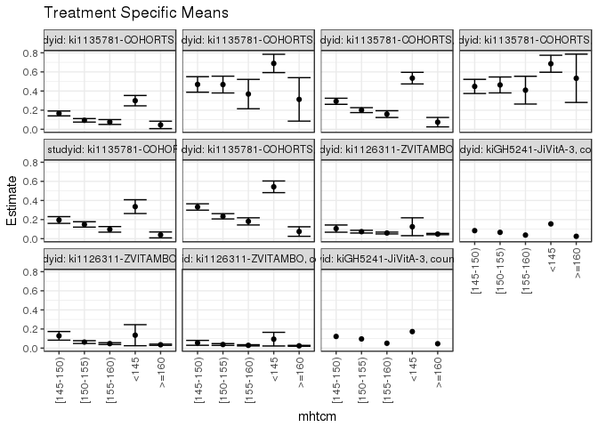

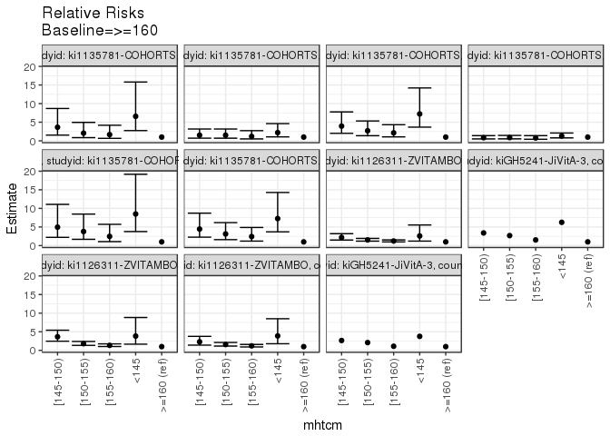

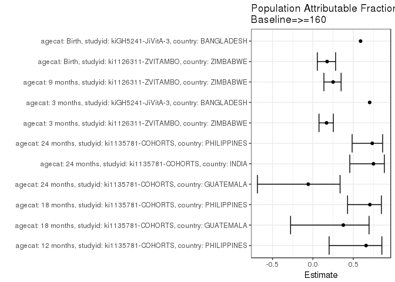

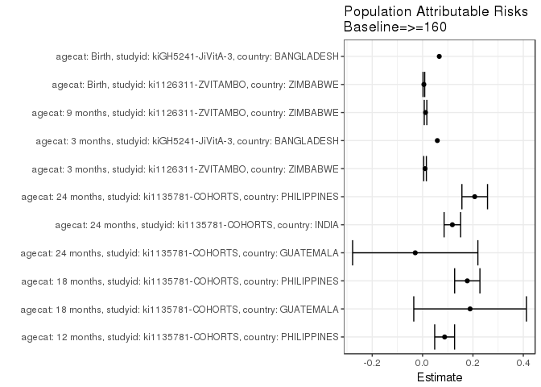

## Results Table

### Parameter: TSM

| agecat | studyid | country | intervention_level | baseline_level | estimate | ci_lower | ci_upper |
| --- | --- | --- | --- | --- | --- | --- | --- |
| Birth | ki1126311-ZVITAMBO | ZIMBABWE | >=160 | NA | 0.0241237 | 0.0198053 | 0.0284421 |
| Birth | ki1126311-ZVITAMBO | ZIMBABWE | <145 | NA | 0.0937500 | 0.0223349 | 0.1651651 |
| Birth | ki1126311-ZVITAMBO | ZIMBABWE | [145-150) | NA | 0.0553746 | 0.0297895 | 0.0809597 |
| Birth | ki1126311-ZVITAMBO | ZIMBABWE | [150-155) | NA | 0.0376884 | 0.0283331 | 0.0470438 |
| Birth | ki1126311-ZVITAMBO | ZIMBABWE | [155-160) | NA | 0.0290820 | 0.0229168 | 0.0352472 |
| Birth | kiGH5241-JiVitA-3 | BANGLADESH | >=160 | NA | 0.0460251 | NA | NA |
| Birth | kiGH5241-JiVitA-3 | BANGLADESH | <145 | NA | 0.1729791 | NA | NA |
| Birth | kiGH5241-JiVitA-3 | BANGLADESH | [145-150) | NA | 0.1220238 | NA | NA |
| Birth | kiGH5241-JiVitA-3 | BANGLADESH | [150-155) | NA | 0.0962276 | NA | NA |
| Birth | kiGH5241-JiVitA-3 | BANGLADESH | [155-160) | NA | 0.0507488 | NA | NA |
| 3 months | ki1126311-ZVITAMBO | ZIMBABWE | >=160 | NA | 0.0483329 | 0.0415746 | 0.0550913 |
| 3 months | ki1126311-ZVITAMBO | ZIMBABWE | <145 | NA | 0.1250000 | 0.0314348 | 0.2185652 |
| 3 months | ki1126311-ZVITAMBO | ZIMBABWE | [145-150) | NA | 0.1054688 | 0.0678404 | 0.1430971 |
| 3 months | ki1126311-ZVITAMBO | ZIMBABWE | [150-155) | NA | 0.0735069 | 0.0593526 | 0.0876612 |
| 3 months | ki1126311-ZVITAMBO | ZIMBABWE | [155-160) | NA | 0.0593627 | 0.0496859 | 0.0690395 |
| 3 months | kiGH5241-JiVitA-3 | BANGLADESH | >=160 | NA | 0.0247678 | NA | NA |
| 3 months | kiGH5241-JiVitA-3 | BANGLADESH | <145 | NA | 0.1548387 | NA | NA |
| 3 months | kiGH5241-JiVitA-3 | BANGLADESH | [145-150) | NA | 0.0840877 | NA | NA |
| 3 months | kiGH5241-JiVitA-3 | BANGLADESH | [150-155) | NA | 0.0664327 | NA | NA |
| 3 months | kiGH5241-JiVitA-3 | BANGLADESH | [155-160) | NA | 0.0376516 | NA | NA |
| 9 months | ki1126311-ZVITAMBO | ZIMBABWE | >=160 | NA | 0.0352436 | 0.0289163 | 0.0415710 |
| 9 months | ki1126311-ZVITAMBO | ZIMBABWE | <145 | NA | 0.1351351 | 0.0249714 | 0.2452988 |
| 9 months | ki1126311-ZVITAMBO | ZIMBABWE | [145-150) | NA | 0.1285714 | 0.0832963 | 0.1738465 |
| 9 months | ki1126311-ZVITAMBO | ZIMBABWE | [150-155) | NA | 0.0631868 | 0.0487554 | 0.0776182 |
| 9 months | ki1126311-ZVITAMBO | ZIMBABWE | [155-160) | NA | 0.0471842 | 0.0378228 | 0.0565456 |
| 12 months | ki1135781-COHORTS | PHILIPPINES | >=160 | NA | 0.0454545 | 0.0065211 | 0.0843880 |
| 12 months | ki1135781-COHORTS | PHILIPPINES | <145 | NA | 0.2992701 | 0.2450371 | 0.3535031 |
| 12 months | ki1135781-COHORTS | PHILIPPINES | [145-150) | NA | 0.1654412 | 0.1399413 | 0.1909410 |
| 12 months | ki1135781-COHORTS | PHILIPPINES | [150-155) | NA | 0.0934579 | 0.0750705 | 0.1118454 |
| 12 months | ki1135781-COHORTS | PHILIPPINES | [155-160) | NA | 0.0758294 | 0.0505672 | 0.1010916 |
| 18 months | ki1135781-COHORTS | GUATEMALA | >=160 | NA | 0.3125000 | 0.0851076 | 0.5398924 |
| 18 months | ki1135781-COHORTS | GUATEMALA | <145 | NA | 0.6888889 | 0.5931286 | 0.7846492 |
| 18 months | ki1135781-COHORTS | GUATEMALA | [145-150) | NA | 0.4689655 | 0.3876408 | 0.5502902 |
| 18 months | ki1135781-COHORTS | GUATEMALA | [150-155) | NA | 0.4677419 | 0.3798138 | 0.5556701 |
| 18 months | ki1135781-COHORTS | GUATEMALA | [155-160) | NA | 0.3684211 | 0.2148644 | 0.5219777 |
| 18 months | ki1135781-COHORTS | PHILIPPINES | >=160 | NA | 0.0740741 | 0.0246721 | 0.1234761 |
| 18 months | ki1135781-COHORTS | PHILIPPINES | <145 | NA | 0.5348837 | 0.4740092 | 0.5957583 |
| 18 months | ki1135781-COHORTS | PHILIPPINES | [145-150) | NA | 0.2928389 | 0.2609378 | 0.3247400 |
| 18 months | ki1135781-COHORTS | PHILIPPINES | [150-155) | NA | 0.2002141 | 0.1745459 | 0.2258824 |
| 18 months | ki1135781-COHORTS | PHILIPPINES | [155-160) | NA | 0.1585366 | 0.1231755 | 0.1938977 |
| 24 months | ki1135781-COHORTS | GUATEMALA | >=160 | NA | 0.5333333 | 0.2806004 | 0.7860663 |
| 24 months | ki1135781-COHORTS | GUATEMALA | <145 | NA | 0.6857143 | 0.5968261 | 0.7746025 |
| 24 months | ki1135781-COHORTS | GUATEMALA | [145-150) | NA | 0.4482759 | 0.3743045 | 0.5222473 |
| 24 months | ki1135781-COHORTS | GUATEMALA | [150-155) | NA | 0.4637681 | 0.3804783 | 0.5470579 |
| 24 months | ki1135781-COHORTS | GUATEMALA | [155-160) | NA | 0.4090909 | 0.2636627 | 0.5545191 |
| 24 months | ki1135781-COHORTS | INDIA | >=160 | NA | 0.0394737 | 0.0085099 | 0.0704375 |
| 24 months | ki1135781-COHORTS | INDIA | <145 | NA | 0.3353659 | 0.2630895 | 0.4076422 |
| 24 months | ki1135781-COHORTS | INDIA | [145-150) | NA | 0.1954733 | 0.1602067 | 0.2307398 |
| 24 months | ki1135781-COHORTS | INDIA | [150-155) | NA | 0.1491086 | 0.1209952 | 0.1772220 |
| 24 months | ki1135781-COHORTS | INDIA | [155-160) | NA | 0.0975000 | 0.0684221 | 0.1265779 |
| 24 months | ki1135781-COHORTS | PHILIPPINES | >=160 | NA | 0.0747664 | 0.0249211 | 0.1246116 |
| 24 months | ki1135781-COHORTS | PHILIPPINES | <145 | NA | 0.5429688 | 0.4819340 | 0.6040035 |
| 24 months | ki1135781-COHORTS | PHILIPPINES | [145-150) | NA | 0.3320413 | 0.2988567 | 0.3652260 |
| 24 months | ki1135781-COHORTS | PHILIPPINES | [150-155) | NA | 0.2342541 | 0.2066548 | 0.2618535 |
| 24 months | ki1135781-COHORTS | PHILIPPINES | [155-160) | NA | 0.1811414 | 0.1435319 | 0.2187510 |

### Parameter: E(Y)

| agecat | studyid | country | intervention_level | baseline_level | estimate | ci_lower | ci_upper |
| --- | --- | --- | --- | --- | --- | --- | --- |
| Birth | ki1126311-ZVITAMBO | ZIMBABWE | NA | NA | 0.0292749 | 0.0259142 | 0.0326355 |
| Birth | kiGH5241-JiVitA-3 | BANGLADESH | NA | NA | 0.1122912 | NA | NA |
| 3 months | ki1126311-ZVITAMBO | ZIMBABWE | NA | NA | 0.0581725 | 0.0529676 | 0.0633773 |
| 3 months | kiGH5241-JiVitA-3 | BANGLADESH | NA | NA | 0.0833674 | NA | NA |
| 9 months | ki1126311-ZVITAMBO | ZIMBABWE | NA | NA | 0.0470105 | 0.0418932 | 0.0521278 |
| 12 months | ki1135781-COHORTS | PHILIPPINES | NA | NA | 0.1330754 | 0.1199794 | 0.1461715 |
| 18 months | ki1135781-COHORTS | GUATEMALA | NA | NA | 0.5012107 | 0.4529305 | 0.5494908 |
| 18 months | ki1135781-COHORTS | PHILIPPINES | NA | NA | 0.2516051 | 0.2345645 | 0.2686458 |
| 24 months | ki1135781-COHORTS | GUATEMALA | NA | NA | 0.5042017 | 0.4592386 | 0.5491648 |
| 24 months | ki1135781-COHORTS | INDIA | NA | NA | 0.1577790 | 0.1410223 | 0.1745357 |
| 24 months | ki1135781-COHORTS | PHILIPPINES | NA | NA | 0.2817996 | 0.2639639 | 0.2996353 |

### Parameter: RR

| agecat | studyid | country | intervention_level | baseline_level | estimate | ci_lower | ci_upper |
| --- | --- | --- | --- | --- | --- | --- | --- |
| Birth | ki1126311-ZVITAMBO | ZIMBABWE | >=160 | >=160 | 1.0000000 | 1.0000000 | 1.000000 |
| Birth | ki1126311-ZVITAMBO | ZIMBABWE | <145 | >=160 | 3.8862179 | 1.7769967 | 8.498997 |
| Birth | ki1126311-ZVITAMBO | ZIMBABWE | [145-150) | >=160 | 2.2954425 | 1.3985336 | 3.767558 |
| Birth | ki1126311-ZVITAMBO | ZIMBABWE | [150-155) | >=160 | 1.5622987 | 1.1504071 | 2.121664 |
| Birth | ki1126311-ZVITAMBO | ZIMBABWE | [155-160) | >=160 | 1.2055355 | 0.9134389 | 1.591038 |
| Birth | kiGH5241-JiVitA-3 | BANGLADESH | >=160 | >=160 | 1.0000000 | NA | NA |
| Birth | kiGH5241-JiVitA-3 | BANGLADESH | <145 | >=160 | 3.7583637 | NA | NA |
| Birth | kiGH5241-JiVitA-3 | BANGLADESH | [145-150) | >=160 | 2.6512445 | NA | NA |
| Birth | kiGH5241-JiVitA-3 | BANGLADESH | [150-155) | >=160 | 2.0907637 | NA | NA |
| Birth | kiGH5241-JiVitA-3 | BANGLADESH | [155-160) | >=160 | 1.1026320 | NA | NA |
| 3 months | ki1126311-ZVITAMBO | ZIMBABWE | >=160 | >=160 | 1.0000000 | 1.0000000 | 1.000000 |
| 3 months | ki1126311-ZVITAMBO | ZIMBABWE | <145 | >=160 | 2.5862299 | 1.2077159 | 5.538211 |
| 3 months | ki1126311-ZVITAMBO | ZIMBABWE | [145-150) | >=160 | 2.1821315 | 1.4875139 | 3.201112 |
| 3 months | ki1126311-ZVITAMBO | ZIMBABWE | [150-155) | >=160 | 1.5208458 | 1.1987681 | 1.929457 |
| 3 months | ki1126311-ZVITAMBO | ZIMBABWE | [155-160) | >=160 | 1.2282052 | 0.9908292 | 1.522450 |
| 3 months | kiGH5241-JiVitA-3 | BANGLADESH | >=160 | >=160 | 1.0000000 | NA | NA |
| 3 months | kiGH5241-JiVitA-3 | BANGLADESH | <145 | >=160 | 6.2516129 | NA | NA |
| 3 months | kiGH5241-JiVitA-3 | BANGLADESH | [145-150) | >=160 | 3.3950393 | NA | NA |
| 3 months | kiGH5241-JiVitA-3 | BANGLADESH | [150-155) | >=160 | 2.6822199 | NA | NA |
| 3 months | kiGH5241-JiVitA-3 | BANGLADESH | [155-160) | >=160 | 1.5201819 | NA | NA |
| 9 months | ki1126311-ZVITAMBO | ZIMBABWE | >=160 | >=160 | 1.0000000 | 1.0000000 | 1.000000 |
| 9 months | ki1126311-ZVITAMBO | ZIMBABWE | <145 | >=160 | 3.8343126 | 1.6640326 | 8.835135 |
| 9 months | ki1126311-ZVITAMBO | ZIMBABWE | [145-150) | >=160 | 3.6480745 | 2.4569849 | 5.416577 |
| 9 months | ki1126311-ZVITAMBO | ZIMBABWE | [150-155) | >=160 | 1.7928571 | 1.3408480 | 2.397242 |
| 9 months | ki1126311-ZVITAMBO | ZIMBABWE | [155-160) | >=160 | 1.3387995 | 1.0244969 | 1.749526 |
| 12 months | ki1135781-COHORTS | PHILIPPINES | >=160 | >=160 | 1.0000000 | 1.0000000 | 1.000000 |
| 12 months | ki1135781-COHORTS | PHILIPPINES | <145 | >=160 | 6.5839414 | 2.7432345 | 15.801888 |
| 12 months | ki1135781-COHORTS | PHILIPPINES | [145-150) | >=160 | 3.6397058 | 1.5244136 | 8.690199 |
| 12 months | ki1135781-COHORTS | PHILIPPINES | [150-155) | >=160 | 2.0560747 | 0.8538134 | 4.951250 |
| 12 months | ki1135781-COHORTS | PHILIPPINES | [155-160) | >=160 | 1.6682464 | 0.6654650 | 4.182107 |
| 18 months | ki1135781-COHORTS | GUATEMALA | >=160 | >=160 | 1.0000000 | 1.0000000 | 1.000000 |
| 18 months | ki1135781-COHORTS | GUATEMALA | <145 | >=160 | 2.2044444 | 1.0509152 | 4.624136 |
| 18 months | ki1135781-COHORTS | GUATEMALA | [145-150) | >=160 | 1.5006897 | 0.7102707 | 3.170720 |
| 18 months | ki1135781-COHORTS | GUATEMALA | [150-155) | >=160 | 1.4967742 | 0.7059342 | 3.173572 |
| 18 months | ki1135781-COHORTS | GUATEMALA | [155-160) | >=160 | 1.1789474 | 0.5096916 | 2.726977 |
| 18 months | ki1135781-COHORTS | PHILIPPINES | >=160 | >=160 | 1.0000000 | 1.0000000 | 1.000000 |
| 18 months | ki1135781-COHORTS | PHILIPPINES | <145 | >=160 | 7.2209302 | 3.6708226 | 14.204400 |
| 18 months | ki1135781-COHORTS | PHILIPPINES | [145-150) | >=160 | 3.9533248 | 2.0113203 | 7.770407 |
| 18 months | ki1135781-COHORTS | PHILIPPINES | [150-155) | >=160 | 2.7028908 | 1.3705117 | 5.330577 |
| 18 months | ki1135781-COHORTS | PHILIPPINES | [155-160) | >=160 | 2.1402439 | 1.0593793 | 4.323894 |
| 24 months | ki1135781-COHORTS | GUATEMALA | >=160 | >=160 | 1.0000000 | 1.0000000 | 1.000000 |
| 24 months | ki1135781-COHORTS | GUATEMALA | <145 | >=160 | 1.2857143 | 0.7866514 | 2.101390 |
| 24 months | ki1135781-COHORTS | GUATEMALA | [145-150) | >=160 | 0.8405172 | 0.5088913 | 1.388252 |
| 24 months | ki1135781-COHORTS | GUATEMALA | [150-155) | >=160 | 0.8695652 | 0.5238620 | 1.443402 |
| 24 months | ki1135781-COHORTS | GUATEMALA | [155-160) | >=160 | 0.7670455 | 0.4241775 | 1.387058 |
| 24 months | ki1135781-COHORTS | INDIA | >=160 | >=160 | 1.0000000 | 1.0000000 | 1.000000 |
| 24 months | ki1135781-COHORTS | INDIA | <145 | >=160 | 8.4959335 | 3.7663422 | 19.164718 |
| 24 months | ki1135781-COHORTS | INDIA | [145-150) | >=160 | 4.9519882 | 2.2142031 | 11.074949 |
| 24 months | ki1135781-COHORTS | INDIA | [150-155) | >=160 | 3.7774170 | 1.6858727 | 8.463793 |
| 24 months | ki1135781-COHORTS | INDIA | [155-160) | >=160 | 2.4699996 | 1.0671808 | 5.716837 |
| 24 months | ki1135781-COHORTS | PHILIPPINES | >=160 | >=160 | 1.0000000 | 1.0000000 | 1.000000 |
| 24 months | ki1135781-COHORTS | PHILIPPINES | <145 | >=160 | 7.2622070 | 3.6935689 | 14.278778 |
| 24 months | ki1135781-COHORTS | PHILIPPINES | [145-150) | >=160 | 4.4410530 | 2.2631593 | 8.714787 |
| 24 months | ki1135781-COHORTS | PHILIPPINES | [150-155) | >=160 | 3.1331492 | 1.5920584 | 6.165995 |
| 24 months | ki1135781-COHORTS | PHILIPPINES | [155-160) | >=160 | 2.4227667 | 1.2052023 | 4.870385 |

### Parameter: PAR

| agecat | studyid | country | intervention_level | baseline_level | estimate | ci_lower | ci_upper |
| --- | --- | --- | --- | --- | --- | --- | --- |
| Birth | ki1126311-ZVITAMBO | ZIMBABWE | >=160 | NA | 0.0051511 | 0.0018000 | 0.0085023 |
| Birth | kiGH5241-JiVitA-3 | BANGLADESH | >=160 | NA | 0.0662661 | NA | NA |
| 3 months | ki1126311-ZVITAMBO | ZIMBABWE | >=160 | NA | 0.0098396 | 0.0046166 | 0.0150625 |
| 3 months | kiGH5241-JiVitA-3 | BANGLADESH | >=160 | NA | 0.0585996 | NA | NA |
| 9 months | ki1126311-ZVITAMBO | ZIMBABWE | >=160 | NA | 0.0117669 | 0.0066217 | 0.0169121 |
| 12 months | ki1135781-COHORTS | PHILIPPINES | >=160 | NA | 0.0876209 | 0.0481454 | 0.1270964 |
| 18 months | ki1135781-COHORTS | GUATEMALA | >=160 | NA | 0.1887107 | -0.0349674 | 0.4123887 |
| 18 months | ki1135781-COHORTS | PHILIPPINES | >=160 | NA | 0.1775311 | 0.1273374 | 0.2277247 |
| 24 months | ki1135781-COHORTS | GUATEMALA | >=160 | NA | -0.0291317 | -0.2778684 | 0.2196051 |
| 24 months | ki1135781-COHORTS | INDIA | >=160 | NA | 0.1183053 | 0.0854524 | 0.1511582 |
| 24 months | ki1135781-COHORTS | PHILIPPINES | >=160 | NA | 0.2070332 | 0.1561884 | 0.2578781 |

### Parameter: PAF

| agecat | studyid | country | intervention_level | baseline_level | estimate | ci_lower | ci_upper |
| --- | --- | --- | --- | --- | --- | --- | --- |
| Birth | ki1126311-ZVITAMBO | ZIMBABWE | >=160 | NA | 0.1759579 | 0.0551125 | 0.2813479 |
| Birth | kiGH5241-JiVitA-3 | BANGLADESH | >=160 | NA | 0.5901272 | NA | NA |
| 3 months | ki1126311-ZVITAMBO | ZIMBABWE | >=160 | NA | 0.1691446 | 0.0756133 | 0.2532122 |
| 3 months | kiGH5241-JiVitA-3 | BANGLADESH | >=160 | NA | 0.7029077 | NA | NA |
| 9 months | ki1126311-ZVITAMBO | ZIMBABWE | >=160 | NA | 0.2503027 | 0.1361426 | 0.3493764 |
| 12 months | ki1135781-COHORTS | PHILIPPINES | >=160 | NA | 0.6584302 | 0.2010773 | 0.8539660 |
| 18 months | ki1135781-COHORTS | GUATEMALA | >=160 | NA | 0.3765097 | -0.2762750 | 0.6954103 |
| 18 months | ki1135781-COHORTS | PHILIPPINES | >=160 | NA | 0.7055940 | 0.4293380 | 0.8481151 |
| 24 months | ki1135781-COHORTS | GUATEMALA | >=160 | NA | -0.0577778 | -0.6863744 | 0.3365093 |
| 24 months | ki1135781-COHORTS | INDIA | >=160 | NA | 0.7498166 | 0.4568713 | 0.8847571 |
| 24 months | ki1135781-COHORTS | PHILIPPINES | >=160 | NA | 0.7346825 | 0.4856757 | 0.8631343 |